# A Trajetória da Ciência Política no Brasil

Institucionalização, expansão da pós-graduação e diversificação temática

Vitor Peixoto — UENF

2026-08-31

## Sessenta anos depois, quanto do que chamamos de “expansão da Ciência Política” é, de fato, Ciência Política?

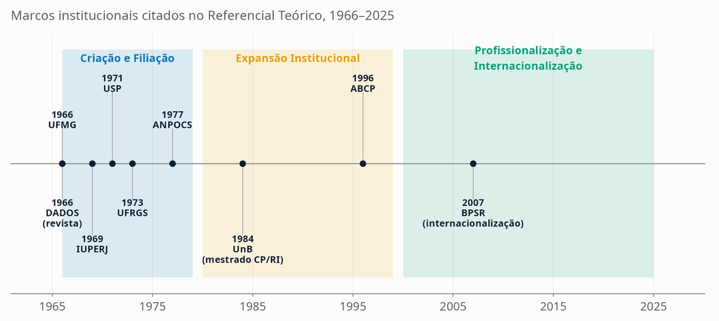

## A pós-graduação como motor de autonomização

- A institucionalização da Ciência Política no Brasil não veio da graduação: foi puxada de cima para baixo pelo sistema de avaliação e fomento da CAPES (Leite 2013)
- A criação da Área 39 deu ao campo critérios próprios de produtividade (Qualis Periódicos) e metas de titulação
- Mas a expansão foi mais lenta que a das áreas irmãs: até a virada do milênio, um “déficit de doutores” atrasou a criação de novos centros fora do eixo Sudeste (Marenco 2014)
- Diferença de origem: Geografia e História cresceram puxadas pela demanda de professores para a educação básica; a Ciência Política nasceu voltada à pesquisa avançada — daí sua menor capilaridade inicial

## O sistema cresceu quase 39 vezes em quatro décadas

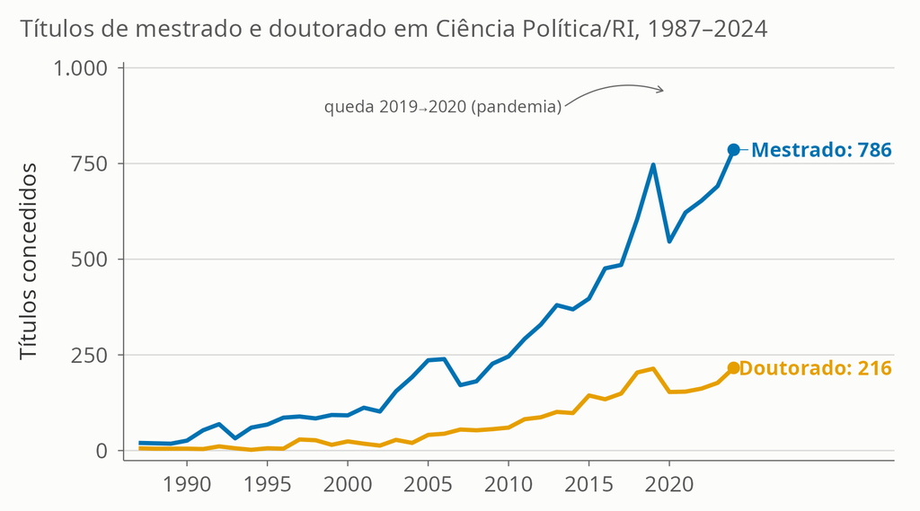

## …e se espalhou pelo território

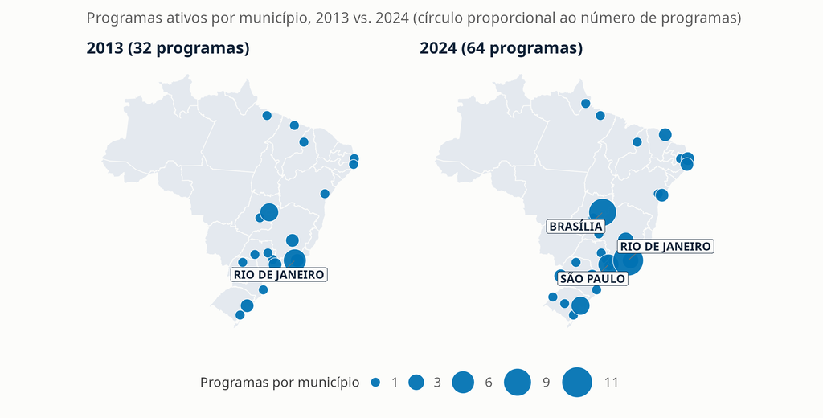

Municípios com programas: 20 (2013) → 29 (2024). Participação do Sudeste: 46,9% → 43,8%.

## Mas é o menor sistema das ciências sociais

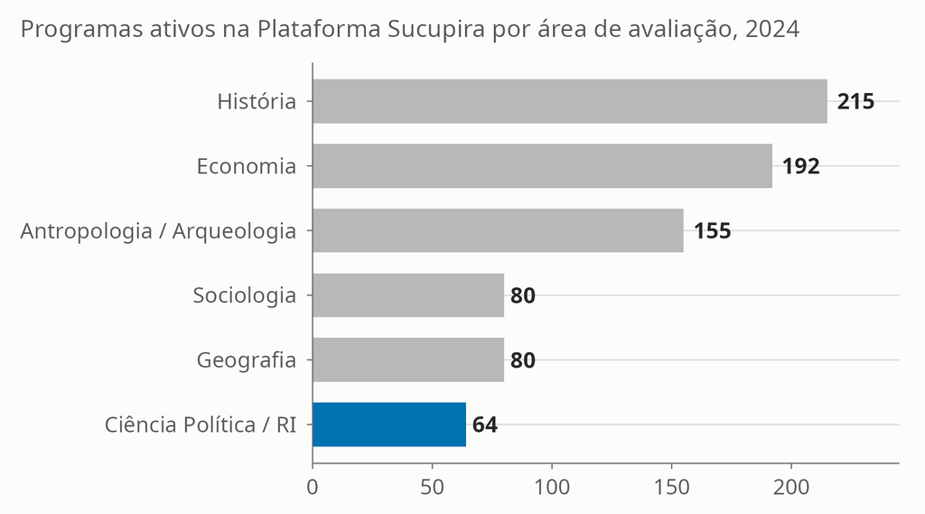

## Em volume, a distância às áreas irmãs é grande — mas o ritmo de crescimento foi o maior de todas

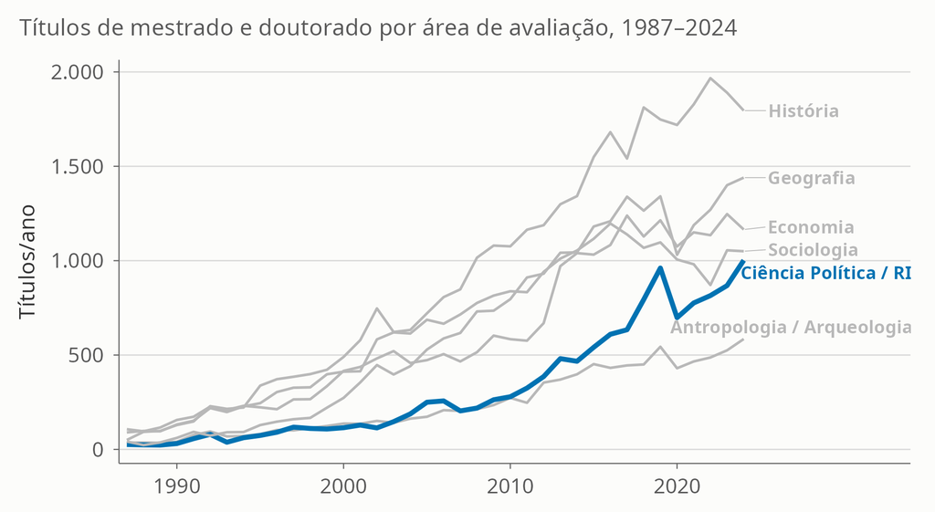

**1987 → 2024, crescimento relativo:**

- Ciência Política/RI: **3.754%**
- Geografia: 3.329%
- História: 3.490%
- Sociologia: 1.067%
- Antropologia: 1.525%
- Economia: 989%

Efeito de base: partiu de **26 títulos** em 1987, o menor patamar inicial do grupo.

## Pequena em escala, intensa na formação

[figure not shown]

### O achado central

## A Área 39 não é a Ciência Política

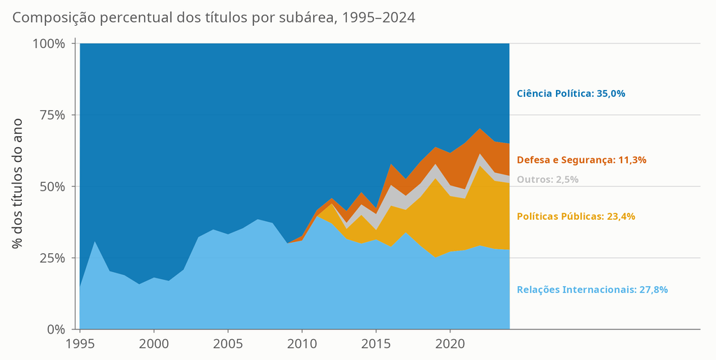

## Defesa e Segurança: um campo novo dentro da área

- Primeiro título registrado em **2010**
- **757 títulos** acumulados até 2024
- **10 programas ativos** em 2024 — quase metade dos 21 de Ciência Política estrita
- Reflete a hibridização da área com a *policy science* e os estudos estratégicos, não apenas crescimento do núcleo disciplinar clássico

## A agenda de pesquisa mudou

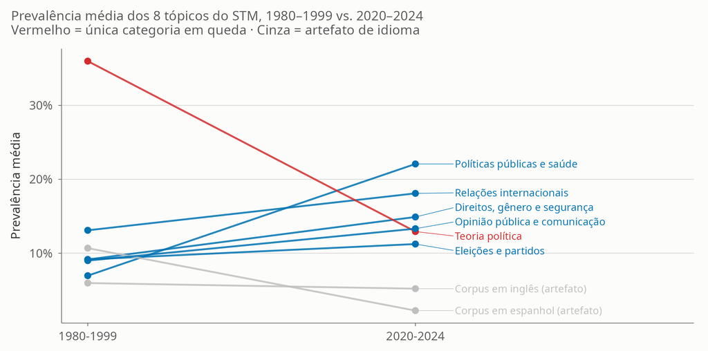

## Os encontros acompanham a escala do sistema

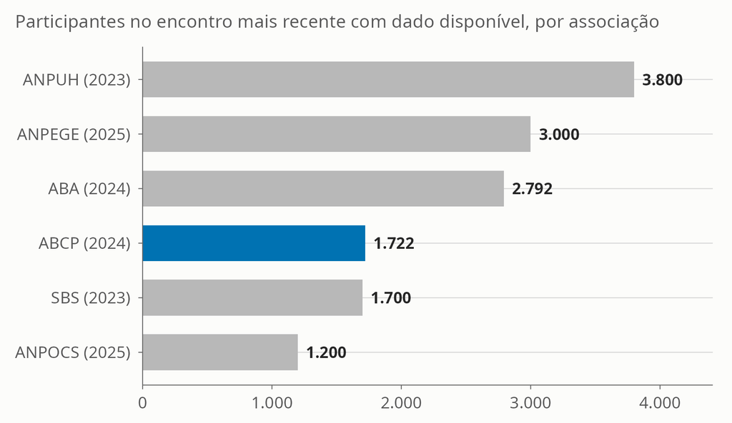

## O que isto não mostra

1. **Mudança metodológica**: descrevemos diversificação *temática*, não desenhos de pesquisa. Uma extensão futura deve classificar explicitamente os métodos usados nos trabalhos.
2. **Comparabilidade perfeita**: áreas de avaliação da CAPES não são disciplinas; os dois layouts históricos do catálogo (1987–2012 e 2013–2024) exigiram âncoras de filtro distintas; a cobertura do OpenAlex é desigual entre periódicos.
3. **Dados ausentes**: sem sexo/gênero nos microdados docentes; sem trajetória completa dos egressos; sem comparação de colaboração internacional entre áreas.

## Conclusão

1. **Escala pequena, ritmo alto.** A Área 39 segue o menor sistema de pós-graduação das ciências sociais em 2024 — mas cresceu mais rápido que todas as áreas irmãs desde 1987, partindo de uma base quase nula.
2. **A área é híbrida.** Só 35,0% dos títulos de 2024 vêm de Ciência Política estrita; o resto é Relações Internacionais, Políticas Públicas e um campo novo — Defesa e Segurança — que não existia como categoria até 2010.
3. **A agenda mudou.** Teoria Política perdeu espaço; políticas públicas, relações internacionais, direitos e opinião pública ganharam.

Sessenta anos depois da criação dos primeiros programas, o retrato é de uma disciplina pequena, mas em expansão consistente e cada vez mais diversa — sem que isso permita atribuir o crescimento a uma política específica.

### Obrigado

**Vitor Peixoto — UENF**

## Reprodutibilidade

- **Repositório:** `/dados/historia_ciencia_politica_brasil`
- **Pipeline:** `SCRIPTS/01` a `SCRIPTS/17`; artigo em `artigo_historia_cp_brasil.qmd`
- **Auditoria de dados:** `AUDITORIA.md`
- **Semente aleatória:** `20260828`

### Referências citadas nesta apresentação

- Forjaz, M. C. S. (1997). *A emergência da Ciência Política acadêmica no Brasil: aspectos institucionais*. RBCS. (Forjaz 1997)
- Lamounier, B. (1989). *A ciência política nos anos 70*. Em: *História das Ciências Sociais no Brasil*. (Lamounier 1989)
- Leite, F. & Codato, A. (2013). *Autonomização e institucionalização da Ciência Política brasileira: o papel do sistema Qualis-Capes*. (Leite 2013)
- Marenco, A. (2014). *The Three Achilles’ Heels of Brazilian Political Science*. BPSR. (Marenco 2014)
- Roberts, M. E. et al. (2014). *Structural Topic Models for Open-Ended Survey Responses*. AJPS. (Roberts et al. 2014)